# Melitz 2003

The Impact of Trade on Intra-Industry Reallocations and Aggregate Industry Productivity

David

LSE

October 9, 2024

## Research question

How does trade shape domestic industry?

## Environment

- Let $i,n$ index countries
- Single Factor of Production: Labour $L$, competitive labour market, inelastic supply
- Dynamic model - we study stationary equilibrium

## Firms - Heterogenous in Productivity

**Firm Decisions**

1. Sunk $f_e$ units of labor to set up
2. Observe permenant productivity draw $\varphi$
   - from exogenous distribution $g_i(\varphi)$
3. Firm choose whether to produce or exit, if produce, whether to export or not
   - per period, to sell to each market $n$, firm pays a fixed cost of $f_{ni}$ in labor
     - equivalent to paying an upfront entry cost
   - additionally, iceberg trade cost $\tau_{ni}$
     - need to send $\tau_{ni}$ unit from $i$ to sell 1 unit in $n$

Each period, there is an exogenous $\delta$ probability of firm death

## Firms - Production

Linear Production Function: $q = \varphi l$

- MC: $\frac{w}{\varphi} = \frac{1}{\varphi}$
  - constant
  - wage $w$ normalized to 1
    - will be equalized across symmetrical countries

## Demand - CES

**Preference:** $C_n = [\int_{\omega \in \Sigma_n} c_n(\omega)^{\rho} d\omega]^{\frac{1}{\rho}}$, with $0<\rho<1$

**Price Index:** $P_n = [\int_{\omega \in \Sigma_n} c_n(\omega)^{1-\sigma} d\omega]^{\frac{1}{1-\sigma}}$, with $\sigma = \frac{1}{1-\rho} >1$, i.e. the elasticity of substitution

Price Index is defined such that $C_n = R_n/P_n$, converting total revenue = total budget into utils.

Consumer optimization gives us demand: $c_n(\omega) =(\frac{p_n(\omega)}{P_n})^{-\sigma} (\frac{R_n}{P_n})$

## Solving the Model

1. Maximize profit in each market
2. Given 1, decide on entry for each market
3. Given 2, decide on whether enter or not as a firm
4. Solve for equlibirums using the firm decisions from 3 by aggregating and impose market clearing conditions

## Firm Maximization

Firms with productivity $\varphi$ from $i$ maxmizes profit in $n$
$$\max_{p(\varphi)} \; \pi_{ni}(\varphi) - f_{ni}$$
i.e.
$$\max_{p(\varphi)} \; p(\varphi)\tau_{ni}c_n(\varphi) - \frac{\tau_{ni}c_n(\varphi)}{\varphi} - f_{ni}$$
FOC gives Inverse Elasticity Pricing: $p(\varphi) = \frac{1}{1-\frac{1}{\sigma}} \frac{1}{\varphi} = \frac{1}{\rho} \frac{1}{\varphi}$

1. $c_n$ demand from before
2. $p(\varphi)$ is gate price at $i$, price charged is $p_{ni} = p(\varphi)\tau_{ni}$

## Exporting Decision

Variable Profit increase in $p(\varphi)$, there exist a threshold $\varphi^{\star}_{ni}$ such that the firm is indifferent to enter $n$

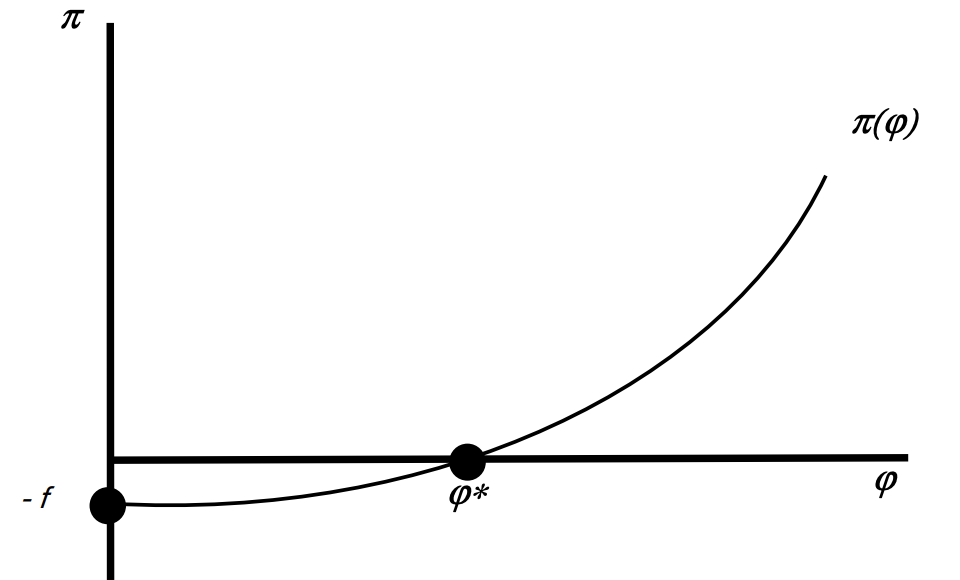

Threshold Productivity

## Exporting Decision - Comparative Statics

We can solve for $\varphi^{\star}_{ni}$ explicitly, plug the pricing equation and demand into the variable profit and we can obtain:
$$\varphi^{\star}_{ni} = (\frac{\sigma}{\rho^{\sigma - 1}}\frac{f_{ni}\tau_{ni}^{\sigma-1}}{R_n P^{\sigma-1}_{n}})^{\frac{1}{1-\sigma}}$$
increasing in trade costs. (This is useful later).

## Entry Decision

We can now determine the firm value. Given a $\varphi$, the per period profit across market is
$$\pi_{i}(\varphi) = \sum_{n}1[\varphi \geq \varphi^{\star}_{ni} ][\pi_{ni}(\varphi) - f_{ni}]$$
We can then discount this value and write the steady state firm value as:
$$v_{i}(\varphi) = \max \{ 0,\frac{\pi_{i}(\varphi)}{\delta} \}$$

Before setting up the firm, the expected firm value is therefore:
$$\bar{v_{i}} = \int v_{i}(\varphi)g_{i}(\varphi)d \varphi$$

## General Equilibrium - Basically

1. N+1 symmetric countries
2. $f_x = f_{ni}$ for $n \neq i$ and $f = f_{ii}$
3. $\tau = \tau_{ni}$ for $n \neq i$ and $1 = \tau_{ii}$

## General Equilibrium - Basically

Two conditions must hold

1. Free Entry:
   $$\bar{v_{i}} = f_{e}$$
   - Entry Decision - No Profit Condition
2. Zero Cutoff:
   $$\varphi^{\star}_{ni} = (\frac{\sigma}{\rho^{\sigma - 1}}\frac{f_{ni}\tau_{ni}^{\sigma-1}}{R_n P^{\sigma-1}_{n}})^{\frac{1}{1-\sigma}}$$
   - Export Decision - Threshold Type Indifferent

## Zero Cutoff Condition

Due to symmetry, the cutoff $\varphi^{\star}_{ni}$ is the same for all the $N$ foreign countries.
$$\varphi^{\star}_{x} = (\frac{\sigma}{\rho^{\sigma - 1}}\frac{f_{x}\tau^{\sigma-1}}{R_n P^{\sigma-1}_{n}})^{\frac{1}{1-\sigma}}$$
We can also write the cutoff for ‘exporting’ to the domestic market, with iceberg cost = 1
$$\varphi^{\star} = \varphi^{\star}_{ii} = (\frac{\sigma}{\rho^{\sigma - 1}}\frac{f}{R_n P^{\sigma-1}_{n}})^{\frac{1}{1-\sigma}}$$
Comparing the two:
$$\frac{\varphi^{\star}_{x}}{\varphi^{\star}} = \tau (\frac{f_x}{f})^{\frac{1}{1-\sigma}} > 1$$

## Selection into Exporting

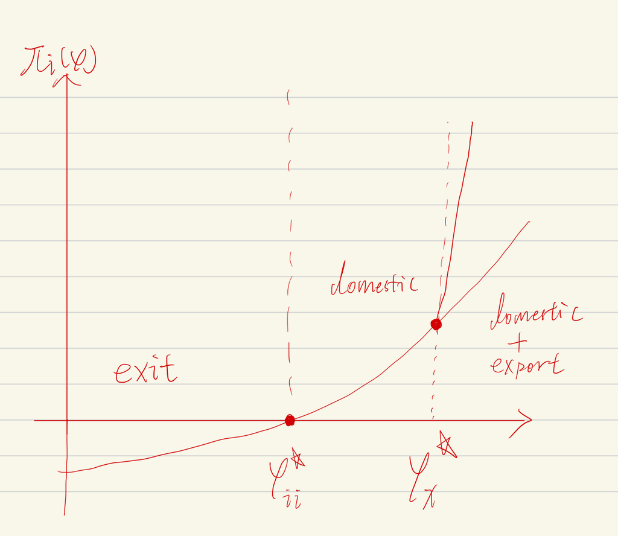

## Free Entry Condition

We can write out the Free Entry Condition:
$$\begin{align}
f_{e} = \bar{v_{i}} &= \int v_{i}(\varphi)g(\varphi) d \varphi \\
& = \int_{\varphi \geq \varphi^{\star}} \frac{\pi_{ii}(\varphi) - f}{\delta} g(\varphi) d \varphi + N \int_{\varphi \geq \varphi^{\star}_{x}} \frac{\pi_{x}(\varphi) - f_x}{\delta} g(\varphi) d \varphi
\end{align}$$

with some algebra, we work out the functional form of $\pi_{ni}$:
$$\begin{align}
f_{e} = \frac{f}{\delta} \int_{\varphi \geq \varphi^{\star}} [(\frac{\varphi}{\varphi^{\star}})^{\sigma-1} - 1] g(\varphi) d \varphi + N \frac{f_x}{\delta} \int_{\varphi \geq \varphi^{\star}_{x}} [(\frac{\varphi}{\varphi^{\star}_{x}})^{\sigma-1} - 1] g(\varphi) d \varphi
\end{align}$$
The first term is domestic variable profit and the second foreign.

## Two Conditions Must Hold - Determines $\varphi^{\star}_{x}$ and $\varphi^{\star}$

Therefore an equilibirum exists!

## Two Conditions Must Hold - Determines $\varphi^{\star}_{x}$ and $\varphi^{\star}$

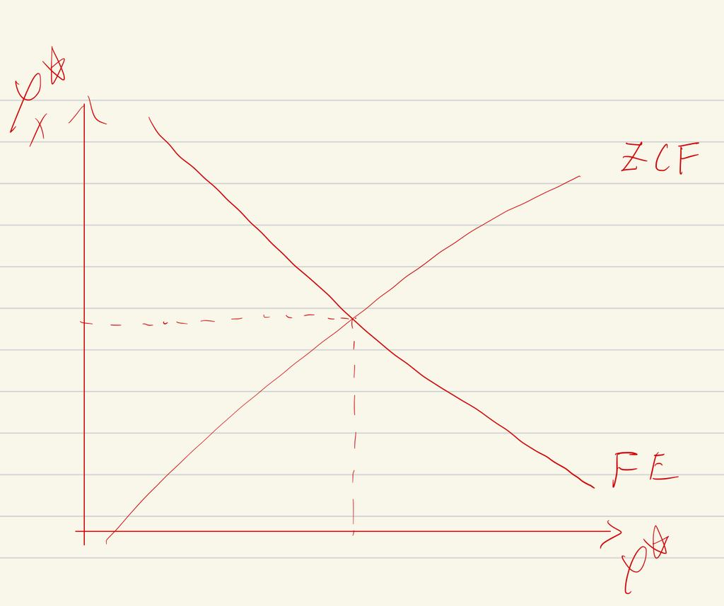

## The Effect of Liberalization - Lowering $\tau$

What happens with liberalization?

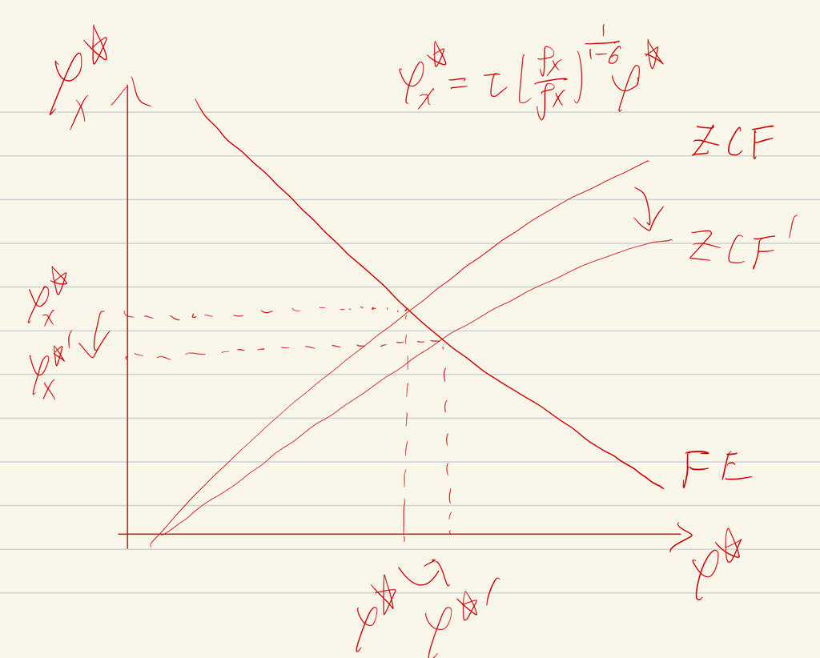

## The Effect of Liberalization - Lowering $\tau$

What happens with liberalization? With import competition:

- The cutoff productivity $\varphi^{\star}$ goes up
  - the least productive firms exit
  - average industry productivity increases
- The cutoff productivity $\varphi^{\star}_{x}$ goes down
  - more firms export
  - average productivity conditional on exporting decreases
- Within industry reallocation improves average productivity, pure selection